# Best Places to Invest an Airbnb Investment Property

Code Part for Airbnb_Zillow Data Analysis  
Xue Ni ni000054@umn.edu

# Set Up and Data Loading

## Package Loading

Required Packages

- `Numpy`, `Pandas` - Data load andmanipulation
- `matplotlib`, `seaborn` - Data visualisation
- `fbprophet` - Time series forecasting

```python
import numpy as np
import pandas as pd
import math

from fbprophet import Prophet # Forecasting

import matplotlib.pyplot as plt
from chart_studio.plotly import plot, iplot
import plotly.graph_objs as go
import seaborn as sns
sns.set_style({'font.family':'Open Sans', 'font.serif':'Computer Modern Roman'})
plt.rcParams['font.sans-serif'] = "Open Sans"

%matplotlib inline
%config InlineBackend.figure_format = 'retina'

import warnings
warnings.filterwarnings('ignore')
```

```python
# set up display area to show dataframe in jupyter, for less truncating
pd.set_option('display.max_rows', 500)
pd.set_option('display.max_columns', 500)
```

## Constant Variables

```python
CITY = 'New York'
NUM_BEDROOM = 2
WORK_DIR = '/Users/xueni/Documents/1_MSBA/Career/Company/Capital_One/DataChallenge/' # where dataset is kept
```

## Data Loading

Revenue(Airbnb) and Cost(Zillow) datasets are loaded into Python-Enviroment for analysis.

```python
import os
os.chdir(WORK_DIR)
zillow_data = pd.read_csv('Zip_Zhvi_2bedroom.csv')
list_data = pd.read_csv('listings.csv')
```

```python
print(list_data.shape)
print(zillow_data.shape)
```

```
(48895, 106)
(8946, 262)
```

The airbnb listings data contains `48895` observations and `106` columns;  
The Zillow dataset contains `8946` rows and `262` columns

```python
list_data.head()
```

|  | id | listing_url | scrape_id | last_scraped | name | summary | space | description | experiences_offered | neighborhood_overview | notes | transit | access | interaction | house_rules | thumbnail_url | medium_url | picture_url | xl_picture_url | host_id | host_url | host_name | host_since | host_location | host_about | host_response_time | host_response_rate | host_acceptance_rate | host_is_superhost | … |
| --- | --- | --- | --- | --- | --- | --- | --- | --- | --- | --- | --- | --- | --- | --- | --- | --- | --- | --- | --- | --- | --- | --- | --- | --- | --- | --- | --- | --- | --- | --- |
| 0 | 2539 | https://www.airbnb.com/rooms/2539 | 20190708031610 | 2019-07-09 | Clean & quiet apt home by the park | Renovated apt home in elevator building. | Spacious, renovated, and clean apt home, one b... | Renovated apt home in elevator building. Spaci... | none | Close to Prospect Park and Historic Ditmas Park | If this room is unavailable on your desired da... | Very close to F and G trains and Express bus i... | NaN | NaN | -The security and comfort of all our guests is... | NaN | NaN | https://a0.muscache.com/im/pictures/3949d073-a... | NaN | 2787 | https://www.airbnb.com/users/show/2787 | John | 2008-09-07 | New York, New York, United States | Educated professional living in Brooklyn. I l... | within an hour | 100% | NaN | f | … |
| 1 | 2595 | https://www.airbnb.com/rooms/2595 | 20190708031610 | 2019-07-09 | Skylit Midtown Castle | Find your romantic getaway to this beautiful, ... | - Spacious (500+ft²), immaculate and nicely fu... | Find your romantic getaway to this beautiful, ... | none | Centrally located in the heart of Manhattan ju... | NaN | Apartment is located on 37th Street between 5t... | Guests have full access to the kitchen, bathro... | I am a Sound Therapy Practitioner and Kundalin... | Make yourself at home, respect the space and t... | NaN | NaN | https://a0.muscache.com/im/pictures/f0813a11-4... | NaN | 2845 | https://www.airbnb.com/users/show/2845 | Jennifer | 2008-09-09 | New York, New York, United States | A New Yorker since 2000! My passion is creatin... | within a few hours | 87% | NaN | f | … |
| 2 | 3647 | https://www.airbnb.com/rooms/3647 | 20190708031610 | 2019-07-08 | THE VILLAGE OF HARLEM....NEW YORK ! | NaN | WELCOME TO OUR INTERNATIONAL URBAN COMMUNITY T... | WELCOME TO OUR INTERNATIONAL URBAN COMMUNITY T... | none | NaN | NaN | NaN | NaN | NaN | Upon arrival please have a legibile copy of yo... | NaN | NaN | https://a0.muscache.com/im/pictures/838341/9b3... | NaN | 4632 | https://www.airbnb.com/users/show/4632 | Elisabeth | 2008-11-25 | New York, New York, United States | Make Up Artist National/ (Website hidden by Ai... | within a day | 100% | NaN | f | … |
| 3 | 3831 | https://www.airbnb.com/rooms/3831 | 20190708031610 | 2019-07-09 | Cozy Entire Floor of Brownstone | Urban retreat: enjoy 500 s.f. floor in 1899 br... | Greetings! We own a double-duplex brownst... | Urban retreat: enjoy 500 s.f. floor in 1899 br... | none | Just the right mix of urban center and local n... | NaN | B52 bus for a 10-minute ride to downtown Brook... | You will have exclusive use of and access to: ... | We'll be around, but since you have the top fl... | Smoking - outside please; pets allowed but ple... | NaN | NaN | https://a0.muscache.com/im/pictures/e49999c2-9... | NaN | 4869 | https://www.airbnb.com/users/show/4869 | LisaRoxanne | 2008-12-07 | New York, New York, United States | Laid-back bi-coastal actor/professor/attorney. | within a few hours | 93% | NaN | f | … |
| 4 | 5022 | https://www.airbnb.com/rooms/5022 | 20190708031610 | 2019-07-08 | Entire Apt: Spacious Studio/Loft by central park | NaN | Loft apartment with high ceiling and wood floo... | Loft apartment with high ceiling and wood floo... | none | NaN | NaN | NaN | NaN | NaN | Please be considerate when staying in the apar... | NaN | NaN | https://a0.muscache.com/im/pictures/feb453bd-f... | NaN | 7192 | https://www.airbnb.com/users/show/7192 | Laura | 2009-01-29 | Miami, Florida, United States | I have been a NYer for almost 10 years. I came... | NaN | NaN | NaN | f | … |

```python
zillow_data.head()
```

|  | RegionID | RegionName | City | State | Metro | CountyName | SizeRank | 1996-04 | 1996-05 | 1996-06 | 1996-07 | 1996-08 | 1996-09 | 1996-10 | 1996-11 | 1996-12 | 1997-01 | 1997-02 | 1997-03 | 1997-04 | 1997-05 | 1997-06 | 1997-07 | 1997-08 | 1997-09 | 1997-10 | 1997-11 | 1997-12 | 1998-01 | … |
| --- | --- | --- | --- | --- | --- | --- | --- | --- | --- | --- | --- | --- | --- | --- | --- | --- | --- | --- | --- | --- | --- | --- | --- | --- | --- | --- | --- | --- | --- | --- |
| 0 | 61639 | 10025 | New York | NY | New York | New York | 1 | NaN | NaN | NaN | NaN | NaN | NaN | NaN | NaN | NaN | NaN | NaN | NaN | NaN | NaN | NaN | NaN | NaN | NaN | NaN | NaN | NaN | NaN | … |
| 1 | 84654 | 60657 | Chicago | IL | Chicago | Cook | 2 | 167700.0 | 166400.0 | 166700.0 | 167200.0 | 166900.0 | 166900.0 | 168000.0 | 170100.0 | 171700.0 | 173000.0 | 174600.0 | 177600.0 | 180100.0 | 182300.0 | 184400.0 | 186300.0 | 187600.0 | 189400.0 | 190300.0 | 189700.0 | 189800.0 | 191900.0 | … |
| 2 | 61637 | 10023 | New York | NY | New York | New York | 3 | NaN | NaN | NaN | NaN | NaN | NaN | NaN | NaN | NaN | NaN | NaN | NaN | NaN | NaN | NaN | NaN | NaN | NaN | NaN | NaN | NaN | NaN | … |
| 3 | 84616 | 60614 | Chicago | IL | Chicago | Cook | 4 | 195800.0 | 193500.0 | 192600.0 | 192300.0 | 192600.0 | 193600.0 | 195500.0 | 197600.0 | 199400.0 | 201300.0 | 203600.0 | 206500.0 | 209200.0 | 211100.0 | 212600.0 | 214400.0 | 215600.0 | 216500.0 | 217900.0 | 220100.0 | 222200.0 | 223900.0 | … |
| 4 | 93144 | 79936 | El Paso | TX | El Paso | El Paso | 5 | 59100.0 | 60500.0 | 60900.0 | 60800.0 | 60300.0 | 60400.0 | 61200.0 | 61700.0 | 61000.0 | 60100.0 | 59300.0 | 59000.0 | 58700.0 | 58400.0 | 58000.0 | 57800.0 | 57900.0 | 57800.0 | 57800.0 | 58100.0 | 58400.0 | 58700.0 | … |

# Data Quality Check and Processing

Check data completeness, accuracy, validity and timeliness for both datasets  
Approach: Define helper functions for each perspective and apply functions on datasets

## Helper Functions for Data Quality Check

### Missing Values

```python
# help fuction
def missing_check(df):
    missing_df = df.isnull().sum(axis=0).reset_index()
    missing_df.columns = ['column_name', 'missing_count']
    missing_df['pct'] = missing_df['missing_count']/df.shape[0]
    #missing_df = missing_df[missing_df['missing_count']>0]
    return missing_df
```

### Negative or Zero Valued Columns

Check negative or zero numerical values and see if those values make sense, if any.

```python
# Define a function to check negative or zero value of dataframe
def NegZero_check(df):
    numerics = ['int16', 'int32', 'int64', 'float16', 'float32', 'float64']
    temp_df = df.select_dtypes(include=numerics)
    NegZero = temp_df.where(temp_df<= 0).count().reset_index()
    NegZero.columns = ['column_name', 'NegZero_count']
    NegZero_df = NegZero[NegZero['NegZero_count']>0]
    NegZero_df['pct'] = NegZero_df['NegZero_count']/df.shape[0]
    return NegZero_df
```

### Duplicated Rows

```python
def duplicated_check(df):
    return df[df.duplicated()].shape[0]
```

## Cost Data

### Quality Check

```python
missing_check(zillow_data).head(10)
```

|  | column_name | missing_count | pct |
| --- | --- | --- | --- |
| 0 | RegionID | 0 | 0.000000 |
| 1 | RegionName | 0 | 0.000000 |
| 2 | City | 0 | 0.000000 |
| 3 | State | 0 | 0.000000 |
| 4 | Metro | 250 | 0.027945 |
| 5 | CountyName | 0 | 0.000000 |
| 6 | SizeRank | 0 | 0.000000 |
| 7 | 1996-04 | 2662 | 0.297563 |
| 8 | 1996-05 | 2582 | 0.288621 |
| 9 | 1996-06 | 2582 | 0.288621 |

It shows that price for early years (1996.04-2013.07) has plenty of missing values. Therefore we need to handle them or will not use data of that time for our model.

```python
NegZero_check(zillow_data)
```

|  | column_name | NegZero_count | pct |
| --- | --- | --- | --- |

There is no Negative or Zero Values in all numeric columns.

```python
duplicated_check(zillow_data)
```

```
0
```

There is no duplicated rows in the Zillow dataset.

### Filter & Clean Data

The various steps performed in the function are as follows:

```python
# This function is to filter city to CITY and keep last num_year years of data
def zillow_filter(df, CITY, num_year):
    """
    CITY: city to filter
    num_year: number of last years to keep
    """

    df = df[df['City']== CITY].copy()
    df = df.drop(["RegionID","City","State",'Metro','SizeRank'],axis=1).copy()
    df = df.rename(columns={"RegionName": "zipcode", 'CountyName':'county'}).copy()

    df = df.iloc[:, np.r_[0:2, df.shape[1]-num_year*12: df.shape[1]]].copy()
    df['zipcode'] = df['zipcode'].astype(str).copy()
    return df
```

```python
# apply above helper function to zillow data
cost7year = zillow_filter(zillow_data, CITY, 7)
```

```python
# This function is to tabulate data from 'wide' to 'long'
def zillow_processing(df):
    df = pd.melt(df, id_vars=['zipcode','county'], value_vars=list(df.columns[2:]))
    df = df.rename(columns={'variable':'yr_mth'}).copy()
    df['yr_mth'] = pd.to_datetime(df['yr_mth'])
    df['zipcode'] = df['zipcode'].astype(str).copy()
    return df
```

```python
cost_long_7yr = zillow_processing(cost7year)
```

### Calculate House Price

```python
# helper func: forecasting price with prophet for single zipcode
def price_forecast_zipcodeWise(df, date, zipcode):  # date in 'yyyy-mm-dd' format

    num_month = math.ceil((pd.to_datetime(date)-pd.to_datetime('2017-06-01'))/np.timedelta64(1,'M'))

    ds_y_df = df.loc[df['zipcode']==zipcode,['yr_mth','value']].rename(columns={"yr_mth": "ds",
                                                                                "value": "y"})
    m = Prophet(weekly_seasonality=True,daily_seasonality=True)
    m.fit(ds_y_df)
    future = m.make_future_dataframe(periods=num_month, freq='M')
    fcst_df = m.predict(future)
    fcst = fcst_df['yhat'].tail(1)
  #  return fcst_df[['ds','yhat']]
    return fcst.array
```

```python
# Forecasting price to July 2019 for each zipcode
def cost_forecast(df_wide, date):
    df_long = zillow_processing(df_wide)
    cost_forecast = df_wide[['zipcode','county']]
    unique_code_list = list(df_wide.zipcode.unique())
    for zipcode in unique_code_list:
        current_price = price_forecast_zipcodeWise(df_long, date, zipcode)
        cost_forecast.loc[(cost_forecast['zipcode'] == zipcode), 'cost'] = current_price
    return cost_forecast
```

```python
cost_2019 = cost_forecast(cost7year,'2019-07-01')
cost_2029 = cost_forecast(cost7year,'2029-07-01')
cost_2030 = cost_forecast(cost7year,'2030-07-01')
```

```python
cost_2029 = pd.merge(cost_2019, cost_2029[['zipcode','cost']], on=['zipcode'],suffixes=['_2019','_2029'])
cost_2030 = pd.merge(cost_2019, cost_2030[['zipcode','cost']], on=['zipcode'],suffixes=['_2019','_2030'])
```

## Revenue Data

### Quality Check

```python
# Only check above relevent columns

airbnb_cols = ['neighbourhood_group_cleansed',
               'city', 'state', 'zipcode', 'latitude', 'longitude','property_type',
               'room_type','bathrooms', 'bedrooms',
               'price', 'weekly_price', 'monthly_price', 'security_deposit','cleaning_fee',
               'number_of_reviews', 'review_scores_rating', 'review_scores_value','reviews_per_month']

list_data = list_data[airbnb_cols]
```

```python
missing_check(list_data)
```

[output not shown]

```python
NegZero_check(list_data)
```

[output not shown]

```python
duplicated_check(list_data)
```

```
0
```

### Filter and Clean Revenue Data

Define Function for Revenue Data Filtering and Cleaning

1. Filter listings having 2 `bedroom`s and only keep relevent columns
2. `Price` column: remove dollar sign and comma; remove observations with zero price; convert to numeric
3. `zipcode` column: trim zipcodes longer than 5 digits and pad ones shorter than 5; convert zipcode into strings

```python
def airbnb_processing(df_airbnb,numberOfBedroom):

    # filter out listings for 2 bedrooms
    df_airbnb = df_airbnb[df_airbnb['bedrooms']==numberOfBedroom].copy()

    relevantcol = ['zipcode','neighbourhood_group_cleansed','latitude','longitude',"price"]

    # due to the incompleteness of weekly price and monthly price, only use price for analysis

    df_airbnb = df_airbnb[relevantcol].rename(columns={'neighbourhood_group_cleansed':'neighbourhood'}).copy()

    # remove observations with null in zipcode
    df_airbnb = df_airbnb[df_airbnb['zipcode'].notnull()].copy()

    # Remove the commas and dollars signs from the price column
    df_airbnb['price'] = df_airbnb['price'].replace({'\$': '', ',': ''}, regex=True).astype(float)

    # There are mixed data types in zipcode column with difference length and formats, convert them all in string and remove noisy characters
    df_airbnb['zipcode'] = df_airbnb['zipcode'].astype(str).replace('\.0', '', regex=True).str.zfill(5).str[:5].copy()

    # remove listings with $0 price
    df_airbnb = df_airbnb[df_airbnb['price']>0].copy()

    return df_airbnb
```

```python
airbnb_2b = airbnb_processing(list_data,NUM_BEDROOM)
```

### Data Integrity

```python
# Check if zipcode vs neighbourhood is one-to-one mapping
def One2One(df, col1, col2):
    df2 = df.groupby([col1,col2]).size().reset_index()
    df3 = pd.DataFrame(df2.groupby(col1).size(), columns=['count'])
    if not df3[df3['count']>1].empty:
        df4=df3[df3['count']>1]
        outlier_ix = df4.index.values[0]
        df_copy = df.copy()
        df_copy.set_index(col1, inplace=True)
        df_outlier = df_copy.ix[df4.index]
        df.loc[df[col1]==outlier_ix,col2] = df_outlier[col2].mode().values[0]
    return df
```

```python
airbnb_2b = One2One(airbnb_2b,'zipcode','neighbourhood')
```

## Data Merging

```python
def merge_air_cost(revenue_df, cost_df):
    combine_data = revenue_df[['zipcode','neighbourhood','price']].merge(cost_df, how='inner',on='zipcode')
    return combine_data
```

```python
data_2019 = merge_air_cost(airbnb_2b, cost_2019)
```

# Exploratory Data Analysis and Visualization

## Housing Price in NYC Over Years

```
WARNING:matplotlib.legend:No handles with labels found to put in legend.
```

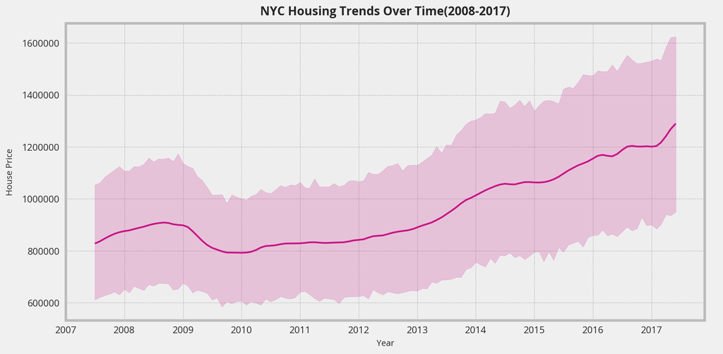

```python
# Code generating Fig1 in the report # Median housing price from 1997 to 2017
data=cost_long10.groupby(['zipcode','yr_mth'],as_index=False)['value'].median()
data2=data.merge(airbnb_2b[['zipcode','neighbourhood']],on='zipcode',how='inner')

plt.figure(figsize=(12,6))
sns.lineplot(data = data, x='yr_mth', y='value',color='mediumvioletred')
plt.xlabel('Year',fontsize=10,labelpad=5)
plt.ylabel('House Price',fontsize=10,labelpad=9)
plt.title("NYC Housing Trends Over Time(2008-2017)", fontsize=14,y=1.01,weight='bold')

#plt.legend(loc='upper right')
plt.legend(loc='upper left',bbox_to_anchor=(1, 1))

plt.show()
```

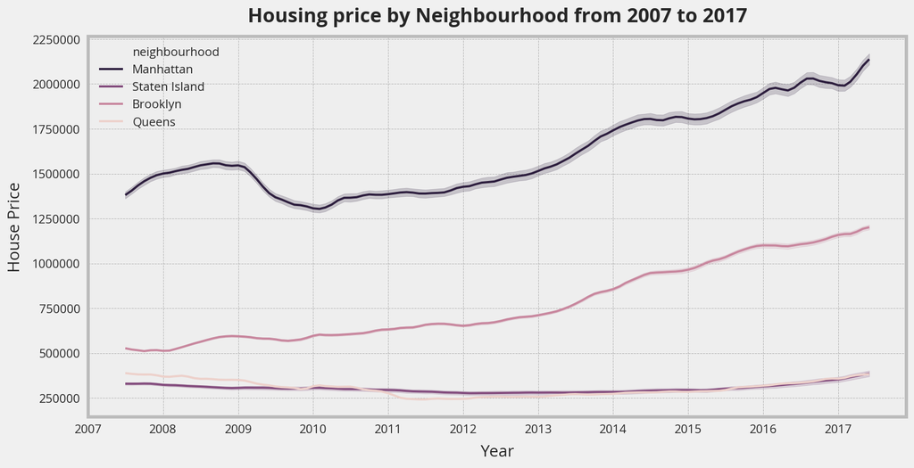

```python
# Code generating Fig2 in the report  # Median housing price within neighbourhood from 1997 to 2017
data=cost_long10.groupby(['zipcode','yr_mth'],as_index=False)['value'].median()
data2=data.merge(airbnb_2b[['zipcode','neighbourhood']],on='zipcode',how='inner')

plt.figure(figsize=(12,6))
sns.lineplot(data = data2, x='yr_mth', y='value',
             hue='neighbourhood',
             palette=sns.cubehelix_palette(reverse=True,n_colors=data2.neighbourhood.nunique()))
plt.xlabel('Year',fontsize=15,labelpad=8)
plt.ylabel('House Price',fontsize=15,labelpad=8)
plt.title('Housing price by Neighbourhood from 2007 to 2017',fontsize=18, y=1.02,weight='bold')

#plt.legend(loc='upper right')
#plt.legend(loc='upper left',bbox_to_anchor=(1, 1))

plt.show()
```

## Airbnb Rental Price within Neighborhood

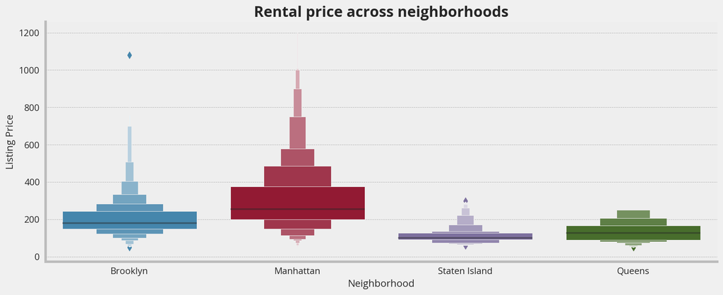

```python
# Code generating Fig3 in the report  # Airbnb rental price within neighbourhood in 2019
df = data_2019[np.abs(data_2019.price-data_2019.price.mean())<=(4*data_2019.price.std())]
# Remove records with listing prices that are more than 3 standard deviations from the mean

plt.figure(figsize=(15,9))
sns.catplot(x='neighbourhood', y="price", kind="boxen", data=df,
            height=5, # make the plot 5 units high
            aspect=2.5) # height should be 3 times width
plt.xlabel('Neighborhood',fontsize=12)
plt.ylabel('Listing Price',fontsize=12)
plt.title('Rental price across neighborhoods',fontsize=18, y=1.2, weight='bold')
plt.show()
```

## Airbnb Rental Price across Zipcodes

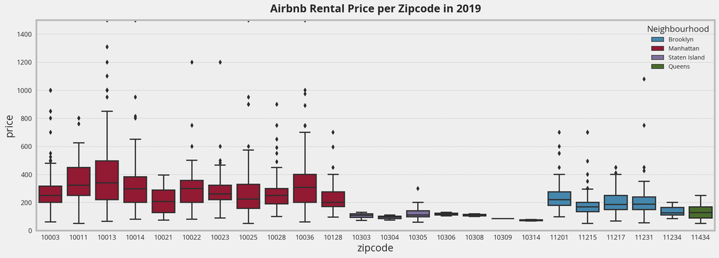

```python
# Code generating Fig4 in the report  # Airbnb rental price within zipcodes in 2019

plt.figure(figsize=(18,6))

ax=sns.boxplot(x='zipcode',y='price',
            hue="neighbourhood",dodge=False,
            data=data_2019)
plt.ylim(0, 1500)
plt.title('Airbnb Rental Price per Zipcode in 2019', fontsize=18, y=1.02, weight='bold')
ax.legend(title="Neighbourhood", fontsize=10)

plt.show()
```

## Rental Property Density across NYC

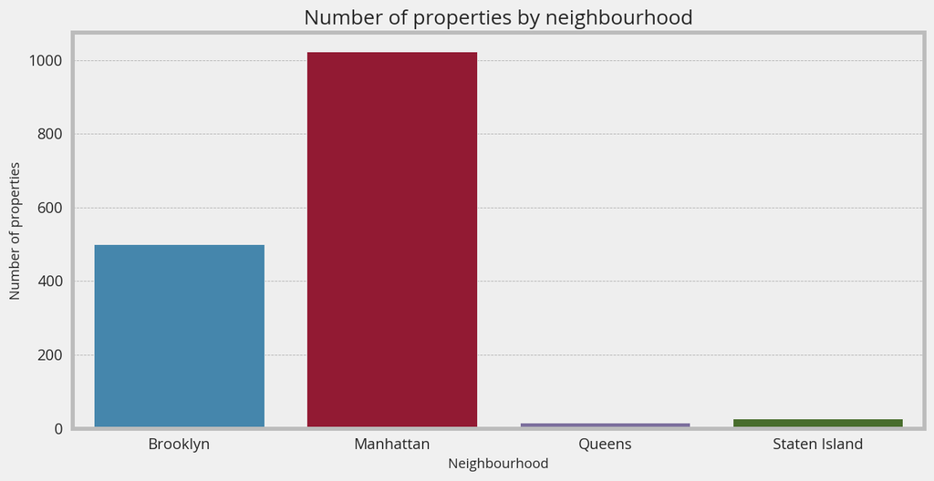

```python
# Code generating Fig5 in the report  # Number of properties by neighbourhood
neigh_list=data_2019.groupby('neighbourhood',as_index=False)['zipcode'].count()

fig, (ax) = plt.subplots(1, 1, figsize=(10,5))

sns.barplot(x="neighbourhood", y="zipcode",data=neigh_list)
plt.title('Number of properties by neighbourhood', fontsize=15)
plt.xlabel('Neighbourhood', fontsize=10)
plt.ylabel('Number of properties', fontsize=10)
plt.show()
```

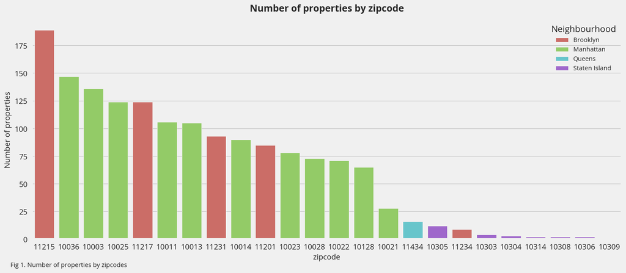

```python
# Code generating Fig6 in the report  # Number of properties by zipcodes

zipcode_list=data_2019.groupby(['zipcode','neighbourhood'],as_index=False)['price'].count()
zipcode_list=zipcode_list.sort_values('price',ascending=False)
fig, (ax) = plt.subplots(1, 1, figsize=(15,6))
plt.style.use('fivethirtyeight')

sns.barplot(x="zipcode", y="price",order=zipcode_list['zipcode'],
            palette="hls",
            hue='neighbourhood',dodge=False,
            data=zipcode_list)
plt.title('Number of properties by zipcode',fontsize=15, y=1.02,weight='bold')
ax.legend(title="Neighbourhood", fontsize=10)
ax.tick_params(axis = 'both', which = 'major', labelsize = 12,)

plt.xlabel('zipcode', fontsize=12)
plt.ylabel('Number of properties', fontsize=12)
plt.text(1, -25, "Fig 1. Number of properties by zipcodes", fontsize=10, ha="center")
plt.show()
```

# Breakeven Analysis

### ROI and Annual Revenue Analysis

**ROI From Rent**

$$ \text{ROI} = \frac{\text{Rental Price}* \text{Occupancy Rate} * \text{Time Period}}{ \text {Total Cost}}$$

**Considering Property Value Appreciation**

$$ \text{ROI} = \frac{\text{Rent}* \text{Occupancy} * \text{Time}+ \text{Appreciation Over Time} }{ \text {Cost}}$$

$$ \text{Breakeven Time} = \frac{1}{\text{ROI}} = \frac{\text{Cost}}{ \text {Rental Price} * \text{Occupancy Rate} * \text{Time Period}}$$

`Time Period` is taken as `year` (365) days

Break even analysis taking the median price;  
For the purpose of decision making, sufficient data points are needed to calculate ROI, hence zipcodes with less than 10 properties are filtered out.

```python
# Function to calculate breakeven time in year, with two aggregation methods
def ROI(df, occupancy):
    temp = df.groupby(['zipcode','neighbourhood']).size()
    df2 = df.groupby(['zipcode','neighbourhood'],as_index=False)['price','cost'].median()\
    .rename(columns={'price':'rent_daily'})

    df2['annual_rent']=df2['rent_daily']*365*occupancy
    df2['num_property'] = temp.values
    df2['breakeven'] = df2['cost']/(df2['rent_daily']*365*occupancy)
    df2['ROI'] = (1/df2['breakeven']).round(2)
    # Remove zipcode with less than 10 listings
    df2 = df2[df2['num_property']>=10]
    df2 = df2.sort_values(by='breakeven')
    return df2
```

```python
# Function to return ROI metrics comparation table of zipcodes
def rent_resale(df_future, year, occupancy):
    temp = df_future.groupby(['zipcode','neighbourhood']).size()
    df_future['appreciation'] = df_future.iloc[:,-1] - df_future['cost_2019']
    df2 = df_future.groupby(['zipcode','neighbourhood'],
                            as_index=False)['price','cost_2019','appreciation'].median() \
    .rename(columns={'price':'rent_daily','cost_2019':'cost'})

    df2['annual_rent']=df2['rent_daily']*365*occupancy
    df2['num_property'] = temp.values
    df2['ROI'] = (df2['annual_rent']*(year-2019)+df2['appreciation'])/(df2['cost']).round(2)
    df2['breakeven'] =(df2['cost']-df2['appreciation'])/(df2['annual_rent']).round(2)

    df3 = df2[df2['num_property']>=10]
    df3=df3.sort_values(by='ROI', ascending=False)
    return df3
```

```python
cost_2029 = cost_forecast(cost7year,'2029-07-01')
cost_2030 = cost_forecast(cost7year,'2030-07-01')

cost_2029 = pd.merge(cost_2019, cost_2029[['zipcode','cost']], on=['zipcode'],suffixes=['_2019','_2029'])
cost_2030 = pd.merge(cost_2019, cost_2030[['zipcode','cost']], on=['zipcode'],suffixes=['_2019','_2030'])
```

```python
payback_2019 = ROI(data_2019, .75)
```

```python
data_2029 = merge_air_cost(airbnb_2b,cost_2029)
data_2030 = merge_air_cost(airbnb_2b,cost_2030)
```

```python
payback_2029 =rent_resale(data_2029,2029,.75)
payback_2030 =rent_resale(data_2030,2030,.75)
```

### Reproducible Function to Generate Plots

```python
# Function generates Figure 7- Annual Gross Revenue
def plots_revenue(df,year):
    f, ax1  = plt.subplots(figsize=(16, 6))
    data=df.sort_values(by='annual_rent',ascending=False)

    splot=sns.barplot(y=data["annual_rent"],
                      x="zipcode",hue='neighbourhood',
                order = data['zipcode'],data=data,dodge=False)
    plt.title('Annual Rental Revenue by the Year of {0}'.format(year),weight="bold", fontsize=18)

    for p in splot.patches:
        width = p.get_width()/2 + p.get_x()
        yloc = p.get_height()
        splot.annotate(format(yloc,'.0f'),
                       (width,yloc),ha = 'center', va='center',
                     xytext=(0, 5),textcoords="offset points")

    ax1.legend(title="Neighbourhood", fontsize=10)
    ax1.tick_params(axis = 'both', which = 'major', labelsize = 12,
                   labelcolor='r', labelsize='medium', width=3)
    plt.xlabel('zipcode', fontsize=12)
    plt.ylabel('Annual Revenue', fontsize=12)

   # plt.text(1, -1000, "Fig 9. Annual Rental Revenue by zipcodes in {}".format(year), fontsize=12, ha="center")
    plt.show()
```

```python
# Function generating Fig7,9,11 in the report
# Break even period by zipcode, color is encoded as neighborhood
def plot_breakeven(df, year):
    plt.style.use('fivethirtyeight')
    fig, (ax) = plt.subplots(1, 1, figsize=(5,8))
    splot=sns.barplot(x="breakeven", y="zipcode",hue='neighbourhood',
                      palette=sns.color_palette('Paired'),
                order = df['zipcode'],
                data=df,orient='h',dodge=False)
    plt.title('Break even time by zipcode in {0}'.format(year),fontsize=15, weight='bold',y=1.02)
    plt.ylabel('Zipcode', fontsize=12)
    plt.xlabel('Breakeven years', fontsize=13)

    for p in splot.patches:
        width = p.get_width()
        yloc = p.get_y() + p.get_height() / 2
        splot.annotate(format(width, '.1f'),
                       (width, yloc),
                    ha = 'center', va='center',
                     xytext=(10, 0),textcoords="offset points")
    ax.tick_params(axis = 'both', which = 'major', labelsize = 12)
    ax.legend(title="Neighbourhood", fontsize=10)
    plt.show()
```

```python
# Function generating Fig9 in the report
def plot_roi(df, year):
    plt.style.use('fivethirtyeight')

    df = df.sort_values('ROI',ascending=False)
    fig, (ax) = plt.subplots(1, 1, figsize=(5,10))
    splot=sns.barplot(x="ROI", y="zipcode",hue='neighbourhood',
                      palette=sns.color_palette('Paired'),
                order = df['zipcode'],
                data=df, orient='h',dodge=False)
    plt.title('ROI by zipcode by the Year of {0}'.format(year),fontsize=15,y=1.01,weight='bold')
    plt.ylabel('Zipcode', fontsize=12)
    plt.xlabel('ROI', fontsize=12)

    for p in splot.patches:
        width = p.get_width()
        yloc = p.get_y() + p.get_height() / 2
        splot.annotate(format(width, '.2f'),
                       (width, yloc),
                    ha = 'center', va='center',
                     xytext=(-14, 0),textcoords="offset points")
    ax.tick_params(axis = 'both', which = 'major', labelsize = 12)
    ax.legend(title="Neighbourhood", fontsize=10)
    plt.show()
```

```python
# Function generates Fig10 in the report  # ROI & Gross Revenue in the future
def plots_ROIvsRevenue(df,year):
    data=df[['annual_rent','breakeven','ROI','zipcode','neighbourhood']]
    data['annual_rent']=(data['annual_rent']* (year-2019))/1000
#    plt.style.use('fivethirtyeight')

    f, (ax1, ax2)  = plt.subplots(1, 2, figsize=(16, 10))

    sns.barplot(x="ROI", y="zipcode",hue='neighbourhood',
                order = data['zipcode'],
            palette="muted",
                data=data, orient='h',dodge=False, ax=ax1)

    sns.barplot(x="annual_rent",
                y="zipcode",hue='neighbourhood',
            palette="muted",
                order = data['zipcode'],
                data=data, orient='h',dodge=False, ax=ax2)

    ax1.set_title('ROI by the Year of {0}'.format(year),fontweight="bold", size=18, pad=10)
    ax2.set_title('Rental Revenue ($ thousand) by the Year of {0}'.format(year),fontweight="bold", size=18,pad=10)
    ax2.set_xlabel('Rent Revenue', fontsize=15)
    ax1.set_xlabel('ROI', fontsize=15)
    ax1.legend(title="Neighbourhood", fontsize=10)

    for p in ax1.patches:
        width = p.get_width()
        yloc = p.get_y() + p.get_height() / 2
        ax1.annotate(format(width, '.2f'),
                    (width, yloc),ha = 'center', va='center',
                     xytext=(-10, 0),textcoords="offset points")

    ax1.tick_params(axis = 'both', which = 'major', labelsize = 11)
    ax2.tick_params(axis = 'both', which = 'major', labelsize = 11)
    plt.tight_layout(pad=4, w_pad=5, h_pad=10)
    ax2.get_legend().remove()
    plt.show()
```

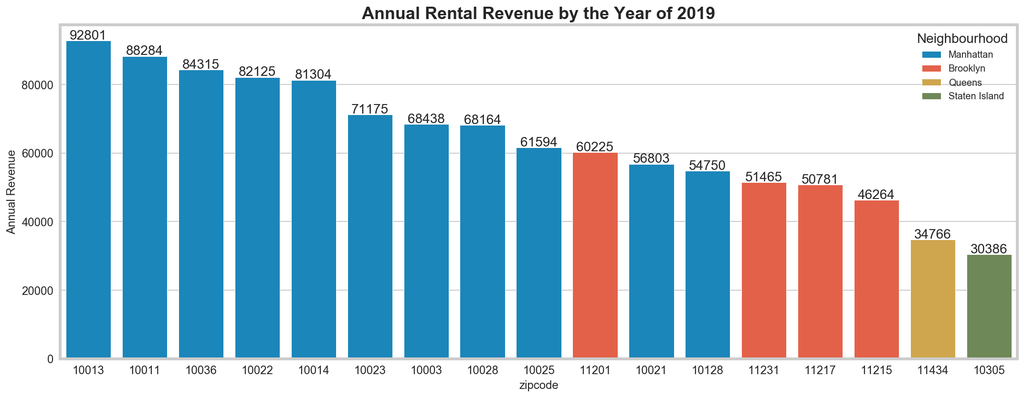

```python
plots_revenue(ROI(data_2019,.75),2019)
```

### Payback After 10 Years

```python
payback_2029 = rent_resale(data_2029,2029,.75)
payback_2029
```

[output not shown]

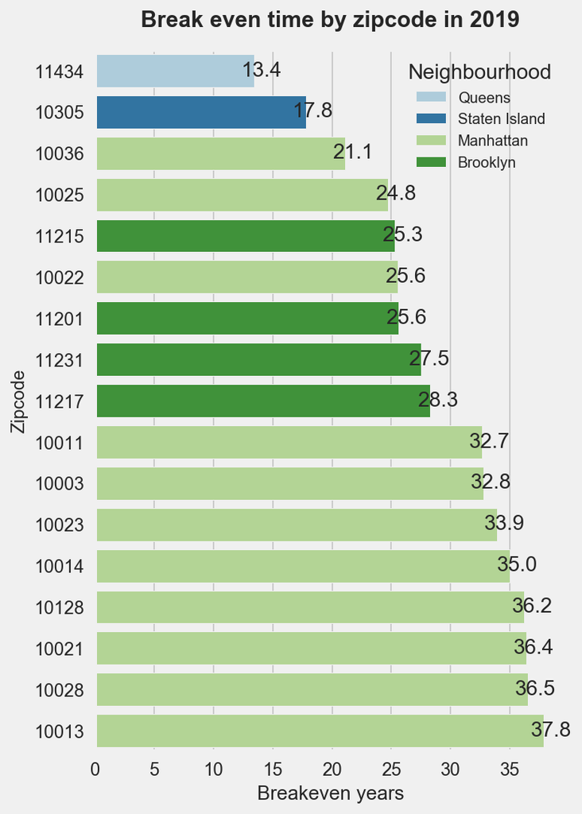

```python
plot_breakeven(payback_2019,2019)
```

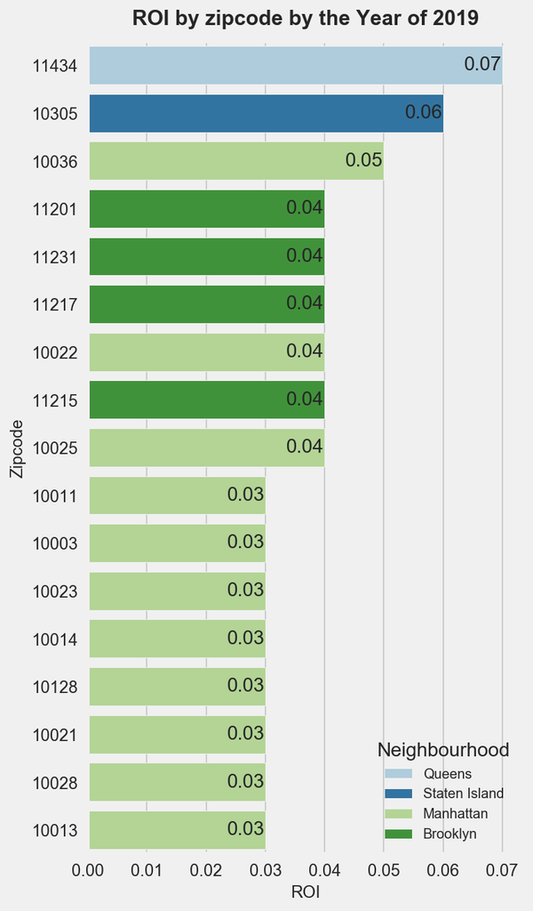

```python
plot_roi(payback_2019,2019)
```

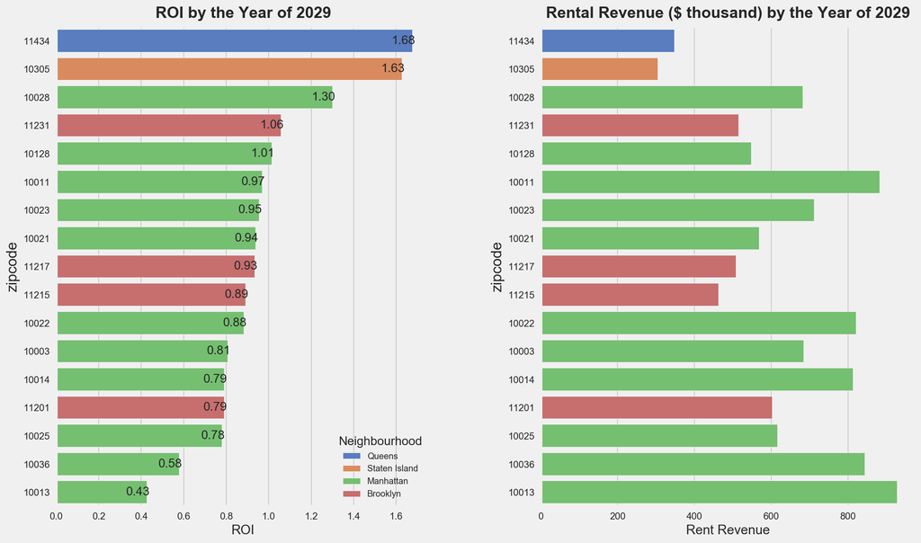

```python
plots_ROIvsRevenue(payback_2029,2029)
```

```python
# generates figure11 in the report
def plot_breakeven2(df, year):
    plt.style.use('fivethirtyeight')
    fig, (ax) = plt.subplots(1, 1, figsize=(15,5))
    splot=sns.barplot(y="breakeven", x="zipcode",hue='neighbourhood',
                      palette=sns.color_palette('Paired'),
                order = df['zipcode'],
                data=df,dodge=False)
    plt.title('Break even time by zipcode in {0}'.format(year),fontsize=15, weight='bold',y=1.02)
    plt.ylabel('Zipcode', fontsize=12)
    plt.xlabel('Breakeven years', fontsize=13)

    ax.tick_params(axis = 'both', which = 'major', labelsize = 12)
    ax.legend(title="Neighbourhood", fontsize=10)
    plt.show()
```

[figure not shown]

```python
plot_breakeven2(payback_2029,2029)
```

# Future Steps

1. A flat occupancy rate of 75% can be corrected with more data. Neighborhoods such as Staten Island have low rent prices but way fewer properties listed. Considering it's location, it is probable they have low occupancy rate but due to the static rate used in the analysis, we have to assume its occupancy to be equal to a property in Manhattan or Brooklyn. Possible solution: Integrate data from public data sources and from related real estate agencies, to build more reliable occupancy rate model.
2. Data, being old, doesn't confirm the actual landscape of market trends. Possible solution: Create a more robust prediction model for current price.
3. Consider seasonality in Airbnb rental prices whenever available to obtain more robust break even estimates. Weekly and monthly rent is cheaper than nightly rent, so considering longer terms would give us the worst-case scenario.
4. Factors such as transportation, proximity to work location can be used to map the area for long-term rentals; Crime score is an important factor in determining the price. Crime score is freely available online and can be used for deeper analysis.
5. Majority of the tourists book short term rentals in NY city hence holidays (variable pricing can be done ) and closeness to tourist locations should be accounted for.